# coding_assignment_3

Shehroz Jawad Khan

Assigned November 5, 2021

##### This homework is due by **11:55 pm on Sunday, November 14, 2021**. To complete this assignment, follow these steps:

1. Download the `coding_assignment_3.Rmd` file from LMS.
2. Open `coding_assignment_3.Rmd` in RStudio.
3. Replace the “Your Name Here” text in the `author:` field with your own name.
4. Supply your solutions to the homework by editing `coding_assignment_3.Rmd`.
5. When you have completed the homework and have **checked** that your code both runs in the Console and knits correctly when you click `Knit HTML`, rename the R Markdown file to `coding_assignment_3_YourNameHere.Rmd`, and submit the markdown AND the html on LMS (YourNameHere should be changed to your own name.)

##### Homework tips:

1. Recall the following useful RStudio hotkeys.

| Keystroke | Description |
| --- | --- |
| `<tab>` | Autocompletes commands and filenames, and lists arguments for functions. |
| `<up>` | Cycles through previous commands in the console prompt |
| `<ctrl-up>` | Lists history of previous commands matching an unfinished one |
| `<ctrl-enter>` | Runs current line from source window to Console. Good for trying things out ideas from a source file. |
| `<ESC>` | Aborts an unfinished command and get out of the + prompt |

**Note**: Shown above are the Windows/Linux keys. For Mac OS X, the `<ctrl>` key should be substituted with the `<command>` (⌘) key.

2. Instead of sending code line-by-line with `<ctrl-enter>`, you can send entire code chunks, and even run all of the code chunks in your .Rmd file. Look under the menu of the Source panel.
3. Run your code in the Console and Knit HTML frequently to check for errors.
4. You may find it easier to solve a problem by interacting only with the Console at first.

```r
#load libraries here
library(readr)
library(psych)
library(reshape)
library(tidyr)
library(dplyr)
library(naniar)
```

```r
#set working directory here
setwd("C:/Users/Admin/Desktop/Fall 2021/Telling Stories with Data/Coding Assignment 3")
```

### Problem 1: Practicing Reshaping Data

##### (a) Diagnosing the problem

We’ll start by loading the `pollution` dataset that has been provided to you on LMS. Load the dataset, and run a few exploratory data analysis commands including `View()` to get a feel of the dataset.

Note that:  
- Air quality varies from 0 (bad quality) to 100 (top good quality)  
- Water pollution varies from 0 (no pollution) to 100 (extreme pollution)

```r
#Your code here
pollution <- read_csv("pollution.csv")
```

```
## * `` -> ...1
```

```r
View(pollution)
```

```r
#To look at the top of our dataframe
head(pollution)
```

```
## # A tibble: 6 x 5
##    ...1 City             Country                  measure        level
##   <dbl> <chr>            <chr>                    <chr>          <dbl>
## 1     1 New York City    United States of America AirQuality      46.8
## 2     2 New York City    United States of America WaterPollution  49.5
## 3     3 Washington, D.C. United States of America AirQuality      66.1
## 4     4 Washington, D.C. United States of America WaterPollution  49.1
## 5     5 San Francisco    United States of America AirQuality      60.5
## 6     6 San Francisco    United States of America WaterPollution  43
```

```r
#To look at the structure of our dataframe: variable names, types, observations
str(pollution)
```

```
## spec_tbl_df [7,926 x 5] (S3: spec_tbl_df/tbl_df/tbl/data.frame)
##  $ ...1   : num [1:7926] 1 2 3 4 5 6 7 8 9 10 ...
##  $ City   : chr [1:7926] "New York City" "New York City" "Washington, D.C." "Washington, D.C." ...
##  $ Country: chr [1:7926] "United States of America" "United States of America" "United States of America" "United States of America" ...
##  $ measure: chr [1:7926] "AirQuality" "WaterPollution" "AirQuality" "WaterPollution" ...
##  $ level  : num [1:7926] 46.8 49.5 66.1 49.1 60.5 ...
##  - attr(*, "spec")=
##   .. cols(
##   ..   ...1 = col_double(),
##   ..   City = col_character(),
##   ..   Country = col_character(),
##   ..   measure = col_character(),
##   ..   level = col_double()
##   .. )
##  - attr(*, "problems")=<externalptr>
```

```r
#To get an idea of the descriptive statistics of our data frame
describe(pollution)
```

```
##          vars    n    mean      sd median trimmed     mad min  max range  skew
## ...1        1 7926 3963.50 2288.18 3963.5 3963.50 2937.77   1 7926  7925  0.00
## City*       2 7926 1889.66 1096.61 1888.0 1888.37 1409.95   1 3796  3795  0.01
## Country*    3 7926  106.54   54.99  120.0  110.14   72.65   1  177   176 -0.33
## measure*    4 7926    1.50    0.50    1.5    1.50    0.74   1    2     1  0.00
## level       5 7926   53.44   29.76   50.0   54.23   37.06   0  100   100 -0.13
##          kurtosis    se
## ...1        -1.20 25.70
## City*       -1.20 12.32
## Country*    -1.31  0.62
## measure*    -2.00  0.01
## level       -0.87  0.33
```

```r
#For more detailed descriptive statistics
summary(pollution)
```

```
##       ...1          City             Country            measure
##  Min.   :   1   Length:7926        Length:7926        Length:7926
##  1st Qu.:1982   Class :character   Class :character   Class :character
##  Median :3964   Mode  :character   Mode  :character   Mode  :character
##  Mean   :3964
##  3rd Qu.:5945
##  Max.   :7926
##      level
##  Min.   :  0.00
##  1st Qu.: 31.73
##  Median : 50.00
##  Mean   : 53.44
##  3rd Qu.: 75.00
##  Max.   :100.00
```

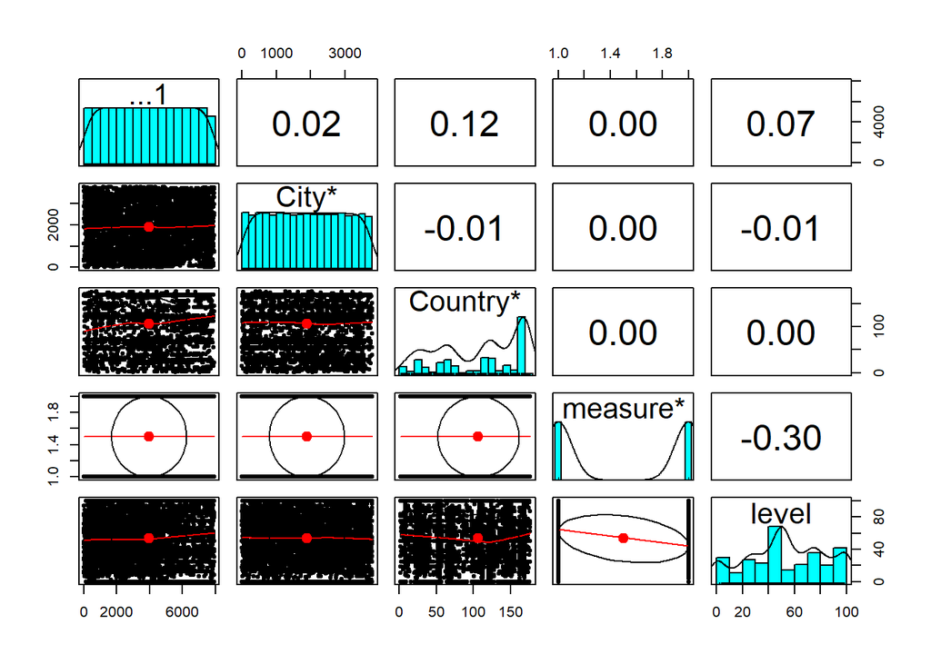

```r
#To get a sense of correlations between different variables
pairs.panels(pollution)
```

What’s one of the issues in the way the data is shaped?

The data is shaped ‘long’ due to which there is duplicity of each observation such that we have two observations for each city relating to Air Quality and Water Pollution.

##### (b) Fixing the problem

Reshape the data to fix the issue you have identified above.

```r
#Your code here
#Reshaping the data from the long format to wide format
pollution <- spread(pollution, measure , level)
pollution
```

```
## # A tibble: 7,926 x 5
##     ...1 City             Country                  AirQuality WaterPollution
##    <dbl> <chr>            <chr>                         <dbl>          <dbl>
##  1     1 New York City    United States of America       46.8           NA
##  2     2 New York City    United States of America       NA             49.5
##  3     3 Washington, D.C. United States of America       66.1           NA
##  4     4 Washington, D.C. United States of America       NA             49.1
##  5     5 San Francisco    United States of America       60.5           NA
##  6     6 San Francisco    United States of America       NA             43
##  7     7 Berlin           Germany                        62.4           NA
##  8     8 Berlin           Germany                        NA             28.6
##  9     9 Los Angeles      United States of America       36.6           NA
## 10    10 Los Angeles      United States of America       NA             61.3
## # ... with 7,916 more rows
```

```r
#Mutating the dataframe such that the value of the previous row is used by the current row
pollution <- mutate(pollution,
                    AirQuality = lead(AirQuality))
#Dropping missing values
pollution <- drop_na(pollution)
pollution
```

```
## # A tibble: 3,962 x 5
##     ...1 City             Country                  AirQuality WaterPollution
##    <dbl> <chr>            <chr>                         <dbl>          <dbl>
##  1     2 New York City    United States of America       66.1           49.5
##  2     4 Washington, D.C. United States of America       60.5           49.1
##  3     6 San Francisco    United States of America       62.4           43
##  4     8 Berlin           Germany                        36.6           28.6
##  5    10 Los Angeles      United States of America       94.3           61.3
##  6    12 Bern             Switzerland                    71.5           12.5
##  7    14 Geneva           Switzerland                    83.8           17.4
##  8    16 Zurich           Switzerland                    81.7           10.7
##  9    18 Basel            Switzerland                    37.0           26.9
## 10    20 London           United Kingdom                 15.8           40.7
## # ... with 3,952 more rows
```

##### (c) Renaming columns

Rearrange and rename the columns in the dataset so that the appear in the following order with the following names:

| var_name | new_name |
| --- | --- |
| Country | country_name |
| City | city_name |
| AirQuality | air_quality |
| WaterPollution | water_pollution |

```r
#your code here
#Renaming variables in the dataframe
names(pollution)[2] <- "city_name"
names(pollution)[3] <- "country_name"
names(pollution)[4] <- "air_quality"
names(pollution)[5] <- "water_pollution"
pollution
```

```
## # A tibble: 3,962 x 5
##     ...1 city_name        country_name             air_quality water_pollution
##    <dbl> <chr>            <chr>                          <dbl>           <dbl>
##  1     2 New York City    United States of America        66.1            49.5
##  2     4 Washington, D.C. United States of America        60.5            49.1
##  3     6 San Francisco    United States of America        62.4            43
##  4     8 Berlin           Germany                         36.6            28.6
##  5    10 Los Angeles      United States of America        94.3            61.3
##  6    12 Bern             Switzerland                     71.5            12.5
##  7    14 Geneva           Switzerland                     83.8            17.4
##  8    16 Zurich           Switzerland                     81.7            10.7
##  9    18 Basel            Switzerland                     37.0            26.9
## 10    20 London           United Kingdom                  15.8            40.7
## # ... with 3,952 more rows
```

```r
#Rearranging the dataframe according to country_name and city_name
pollution <- pollution[,c(1,3,2,4,5)]
pollution
```

```
## # A tibble: 3,962 x 5
##     ...1 country_name             city_name        air_quality water_pollution
##    <dbl> <chr>                    <chr>                  <dbl>           <dbl>
##  1     2 United States of America New York City           66.1            49.5
##  2     4 United States of America Washington, D.C.        60.5            49.1
##  3     6 United States of America San Francisco           62.4            43
##  4     8 Germany                  Berlin                  36.6            28.6
##  5    10 United States of America Los Angeles             94.3            61.3
##  6    12 Switzerland              Bern                    71.5            12.5
##  7    14 Switzerland              Geneva                  83.8            17.4
##  8    16 Switzerland              Zurich                  81.7            10.7
##  9    18 Switzerland              Basel                   37.0            26.9
## 10    20 United Kingdom           London                  15.8            40.7
## # ... with 3,952 more rows
```

##### (d) Rearranging the data

Rearrange the way your data is organized so that the countries and cities appear in alphabetical order i.e. All countries should be sorted alphabetically, and each city within each city should appear alphabetically.

```r
#Your code here
pollution <- pollution %>%
  arrange(country_name, city_name)
pollution
```

```
## # A tibble: 3,962 x 5
##     ...1 country_name city_name      air_quality water_pollution
##    <dbl> <chr>        <chr>                <dbl>           <dbl>
##  1  7024 Afghanistan  Andkhoy               25              50
##  2  5572 Afghanistan  Farah                 39.3             0
##  3  2086 Afghanistan  Herat                 82.4            31.2
##  4   890 Afghanistan  Kabul                 25              81.1
##  5  2090 Afghanistan  Kandahar             100              75
##  6  2996 Afghanistan  Mazar-i-Sharif        75              83.3
##  7  5954 Albania      Ballsh                50              62.5
##  8  5030 Albania      Burrel                65              62.5
##  9  2746 Albania      Durres                 0              62.5
## 10  2902 Albania      Elbasan               56.2            25
## # ... with 3,952 more rows
```

##### (e) Creating Country Level Summaries

Create a new dataset called `country_stats` that contains the mean, median, min, and max air pollution for each country.

```r
#Your code here
#Grouping a new dataframe by country
country_grouped <- group_by(pollution, country_name)

#Storing the required statistics in a new variable called 'country_stats'
country_stats <- summarise(country_grouped,
                           mean = mean(air_quality),
                           median = median(air_quality),
                           min = min(air_quality),
                           max = max(air_quality))

country_stats
```

```
## # A tibble: 177 x 5
##    country_name  mean median   min   max
##    <chr>        <dbl>  <dbl> <dbl> <dbl>
##  1 Afghanistan   57.8   57.1  25   100
##  2 Albania       53.7   53.1   0   100
##  3 Algeria       75.3   83.3   0   100
##  4 Andorra       62.4   62.4  39.4  85.4
##  5 Angola        93.8   93.8  93.8  93.8
##  6 Argentina     75.9   75    18.1 100
##  7 Armenia       58.3   62.5  25    87.5
##  8 Australia     68.6   81.2   0   100
##  9 Austria       74.5   82.8   0   100
## 10 Azerbaijan    44.6   44.6  44.6  44.6
## # ... with 167 more rows
```

##### (f) Finding countries at the highest airquality levels

Create a new dataset named `at_risk_countries` that contains mean airquality levels ONLY for counries that have lower than the WORLD average airquality level. To calculate the world average, you can simply take the average of every country’s average AQI.

```r
#Your code here
#Checking the world average mean by taking the average of AQI
mean(pollution$air_quality)
```

```
## [1] 62.25735
```

```r
#Creating a new dataframe with countries that have lower than world average AQI
at_risk_countries <- filter(country_grouped, air_quality < mean(air_quality))
at_risk_countries <- summarise(at_risk_countries, mean_air_quality = mean(air_quality))
at_risk_countries
```

```
## # A tibble: 143 x 2
##    country_name mean_air_quality
##    <chr>                   <dbl>
##  1 Afghanistan              29.8
##  2 Albania                  28.1
##  3 Algeria                  44.4
##  4 Andorra                  39.4
##  5 Argentina                61.0
##  6 Armenia                  25
##  7 Australia                30.5
##  8 Austria                  46.2
##  9 Bahrain                  87.5
## 10 Bangladesh               28.2
## # ... with 133 more rows
```

```r
at_risk_countries$country_name[which.min(at_risk_countries$mean_air_quality)]
```

```
## [1] "Bhutan"
```

##### (g) Finding he countries at highest risk.

Use inline coding to report how many countries have air quality levels worse than the world average. Also use the space below to discuss which country has the worst airquality.

There are 143 countries having AQI worse than the world average. Country with the worse AQI is Bhutan with an average AQI of 15.

### Problem 2: More practice with Dplyr

##### (a) Finding the most polluted cities for each country

Create a new dataframe that shows information on ONLY the cities that have the lowest air quality for each country. Your final dataframe should have three columns: `country_name`, `city_name` (city with the lowest airquality), and `air_quality` (corresponding airquality).

**HINT**: There are, as always, many ways to do this. You may find it most efficient to try using a new dplyr verb called `slice()`. Read the documentation here. https://dplyr.tidyverse.org/reference/slice.html

```r
# Your code here
cities_most_polluted <-
    pollution %>%
    group_by(country_name) %>%
    slice(unique(c(which(city_name == 0), which.min(air_quality)))) %>%
    select(country_name, city_name, air_quality)
head(cities_most_polluted)
```

```
## # A tibble: 6 x 3
## # Groups:   country_name [6]
##   country_name city_name        air_quality
##   <chr>        <chr>                  <dbl>
## 1 Afghanistan  Andkhoy                 25
## 2 Albania      Durres                   0
## 3 Algeria      Bejaia                   0
## 4 Andorra      Andorra la Vella        39.4
## 5 Angola       Luanda                  93.8
## 6 Argentina    Buenos Aires            18.1
```

##### (b) Finding the difference between the most and least polluted cities

Create a new dataset that reports the difference between the highest and lowest airquality cities in each country. Your final dataset should contain the following columns: `country_name`, `worst_airquality`, `best_airquality`, `variation`.

```r
# Your code here
difference_in_maxmin_airquality <- summarise(country_grouped, best_airquality = max(air_quality), worst_airquality = min(air_quality), variation = best_airquality - worst_airquality)
head(difference_in_maxmin_airquality)
```

```
## # A tibble: 6 x 4
##   country_name best_airquality worst_airquality variation
##   <chr>                  <dbl>            <dbl>     <dbl>
## 1 Afghanistan            100               25        75
## 2 Albania                100                0       100
## 3 Algeria                100                0       100
## 4 Andorra                 85.4             39.4      46.0
## 5 Angola                  93.8             93.8       0
## 6 Argentina              100               18.1      81.9
```

### Problem 3:Practice with Data Cleaning

##### (a) Diagnosing the problem

For this problem, start by loading the `metal_bands` dataset that has been provided to you on LMS. Load the dataset, and run a few exploratory data analysis commands including `View()` to get a feel of the dataset. Pay special attention to the datatypes.

```r
# Import data file here
metal_bands_2017 <- read_csv("C:/Users/Admin/Desktop/Fall 2021/Telling Stories with Data/Coding Assignment 3/metal_bands_2017.csv")
View(metal_bands_2017)
```

```r
head(metal_bands_2017)
```

```
## # A tibble: 6 x 6
##   band_name    fans formed origin         split style
##   <chr>       <dbl>  <dbl> <chr>          <chr> <chr>
## 1 Iron Maiden  4195   1975 United Kingdom -     New wave of british heavy,Heavy
## 2 Opeth        4147   1990 Sweden         1990  Extreme progressive,Progressive~
## 3 Metallica    3712   1981 USA            -     Heavy,Bay area thrash
## 4 Megadeth     3105   1983 USA            1983  Thrash,Heavy,Hard rock
## 5 Amon Amarth  3054   1988 Sweden         -     Melodic death
## 6 Slayer       2955   1981 USA            1981  Thrash
```

```r
str(metal_bands_2017)
```

```
## spec_tbl_df [5,000 x 6] (S3: spec_tbl_df/tbl_df/tbl/data.frame)
##  $ band_name: chr [1:5000] "Iron Maiden" "Opeth" "Metallica" "Megadeth" ...
##  $ fans     : num [1:5000] 4195 4147 3712 3105 3054 ...
##  $ formed   : num [1:5000] 1975 1990 1981 1983 1988 ...
##  $ origin   : chr [1:5000] "United Kingdom" "Sweden" "USA" "USA" ...
##  $ split    : chr [1:5000] "-" "1990" "-" "1983" ...
##  $ style    : chr [1:5000] "New wave of british heavy,Heavy" "Extreme progressive,Progressive rock,Progressive" "Heavy,Bay area thrash" "Thrash,Heavy,Hard rock" ...
##  - attr(*, "spec")=
##   .. cols(
##   ..   band_name = col_character(),
##   ..   fans = col_double(),
##   ..   formed = col_double(),
##   ..   origin = col_character(),
##   ..   split = col_character(),
##   ..   style = col_character()
##   .. )
##  - attr(*, "problems")=<externalptr>
```

```r
describe(metal_bands_2017)
```

```
##            vars    n    mean      sd median trimmed     mad  min  max range
## band_name*    1 5000 2472.66 1427.13 2470.5 2472.26 1831.01    1 4949  4948
## fans          2 5000   87.81  296.14   12.0   25.01   14.83    0 4195  4195
## formed        3 4996 2000.42    8.88 2002.0 2001.13    8.90 1964 2016    52
## origin*       4 4992   73.04   36.34   83.0   75.69   44.48    1  115   114
## split*        5 5000   20.08   18.27   23.0   19.20   32.62    1   50    49
## style*        6 5000  598.00  355.38  600.0  590.90  477.40    1 1227  1226
##             skew kurtosis    se
## band_name*  0.00    -1.20 20.18
## fans        7.05    64.28  4.19
## formed     -0.74     0.25  0.13
## origin*    -0.35    -1.40  0.51
## split*      0.10    -1.72  0.26
## style*      0.09    -1.24  5.03
```

```r
summary(metal_bands_2017)
```

```
##   band_name              fans             formed        origin
##  Length:5000        Min.   :   0.00   Min.   :1964   Length:5000
##  Class :character   1st Qu.:   4.00   1st Qu.:1995   Class :character
##  Mode  :character   Median :  12.00   Median :2002   Mode  :character
##                     Mean   :  87.81   Mean   :2000
##                     3rd Qu.:  42.00   3rd Qu.:2007
##                     Max.   :4195.00   Max.   :2016
##                                       NA's   :4
##     split              style
##  Length:5000        Length:5000
##  Class :character   Class :character
##  Mode  :character   Mode  :character
##
##
##
##
```

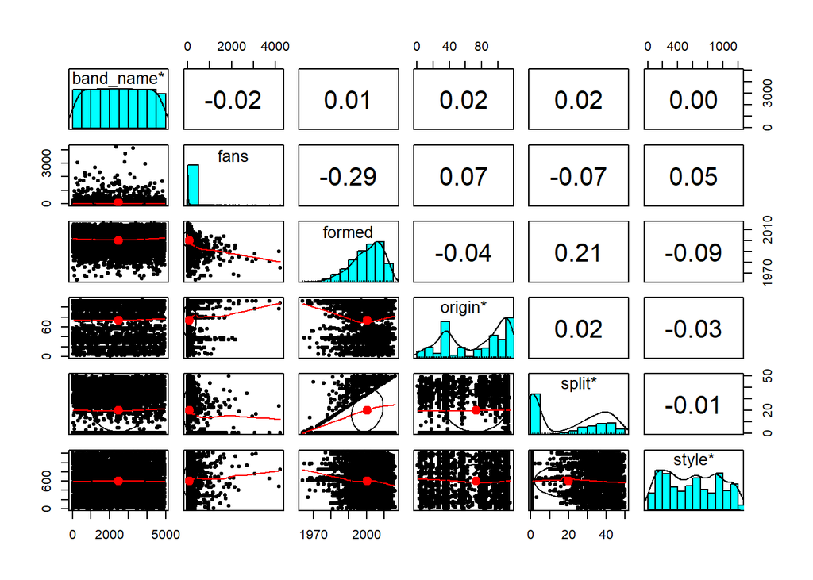

```r
pairs.panels(metal_bands_2017)
```

##### (a) Cleaning up the missing values

How does this dataset deal with missing values? Can you replace all instances of missing values with the correct format for missing values i.e. `NA`

```r
# Your code here
#We see that missing values are denoted by '-' in the split variable
metal_bands_2017$split <- as.numeric(metal_bands_2017$split)
typeof(metal_bands_2017$split)
```

```
## [1] "double"
```

```r
str(metal_bands_2017$split)
```

```
##  num [1:5000] NA 1990 NA 1983 NA ...
```

##### (b) Creating a new subset

Suppose you ONLY want to look at bands from the 90s and the 2000s. Create a new dataset that contains information ONLY from bands that were formed between 1990 and 2010.

```r
# Your code here
bands_90s_2000s <- subset(metal_bands_2017, formed >= 1990 & formed <= 2010,
                          select = c(band_name, fans, formed, origin, split, style))
bands_90s_2000s
```

```
## # A tibble: 3,834 x 6
##    band_name          fans formed origin  split style
##    <chr>             <dbl>  <dbl> <chr>   <dbl> <chr>
##  1 Opeth              4147   1990 Sweden   1990 Extreme progressive,Progressive~
##  2 Nightwish          2183   1996 Finland  1996 Symphonic power,Gothic,Symphonic
##  3 Children Of Bodom  2153   1993 Finland    NA Extreme power
##  4 In Flames          1932   1990 Sweden   1990 Gothenburg,Alternative
##  5 Agalloch           1881   1995 USA      2016 Atmospheric black,Neofolk
##  6 Ensiferum          1879   1995 Finland  1995 Extreme folk
##  7 Arch Enemy         1750   1996 Sweden     NA Gothenburg
##  8 Katatonia          1735   1991 Sweden   1991 Blackened doom,Death doom,Alter~
##  9 Behemoth           1721   1991 Poland     NA Death,Black,Blackened death
## 10 Dimmu Borgir       1688   1993 Norway   1993 Symphonic black,Black
## # ... with 3,824 more rows
```

##### (c) Adding a new variable

Add a new variable to your subsetted dataframe called `decade` that takes the values “1990s” if the band was formed in the 1990s and “2000s” if the band was formed in the 2000s.

```r
# Your code here
bands_90s_2000s <- bands_90s_2000s <- bands_90s_2000s %>%
  mutate(decade = case_when(formed >= 1990 & formed < 2001 ~ "1990s",
                         formed >= 2001 & formed < 2011 ~ "2000s"
  ))
head(bands_90s_2000s)
```

```
## # A tibble: 6 x 7
##   band_name          fans formed origin  split style                      decade
##   <chr>             <dbl>  <dbl> <chr>   <dbl> <chr>                      <chr>
## 1 Opeth              4147   1990 Sweden   1990 Extreme progressive,Progr~ 1990s
## 2 Nightwish          2183   1996 Finland  1996 Symphonic power,Gothic,Sy~ 1990s
## 3 Children Of Bodom  2153   1993 Finland    NA Extreme power              1990s
## 4 In Flames          1932   1990 Sweden   1990 Gothenburg,Alternative     1990s
## 5 Agalloch           1881   1995 USA      2016 Atmospheric black,Neofolk  1990s
## 6 Ensiferum          1879   1995 Finland  1995 Extreme folk               1990s
```

##### (d) Were metal bands in the 1990s more popular than metal bands in the 2000s?

Create a summary table that shows the total number of metal band fans by decade.

```r
# Your code here
fans_by_decade <- group_by(bands_90s_2000s,decade)
fans_by_decade <- summarise(fans_by_decade, sum_fans = sum(fans))
fans_by_decade
```

```
## # A tibble: 2 x 2
##   decade sum_fans
##   <chr>     <dbl>
## 1 1990s    194397
## 2 2000s     77312
```

```r
fans_by_decade[which.min(fans_by_decade$sum_fans),1]
```

```
## # A tibble: 1 x 1
##   decade
##   <chr>
## 1 2000s
```

Use inline coding to report which year the metal genre was more popular in.

The metal genre was more popular in 1990s.

### Problem 4: Evolved group analysis

##### (a) Does the USA produce more death metal bands than the UK?

Go back to your original dataframe with the full range of years. Create a summary table that shows the counts of bands from the UK and the USA.

**Hint**: You may need to do some data cleaning to get the right values for UK and USA. Try to diagnose the issue by running this command: `levels(as.factor(metal_bands$origin))`. Once you have diagnosed the issues, think about which method might be best to fix it. You may find the `gsub()` function useful here.

```r
levels(as.factor(metal_bands_2017$origin))
```

```
##   [1] "Albania"                         "Andorra"
##   [3] "Argentina"                       "Armenia"
##   [5] "Australia"                       "Australia, United Kingdom"
##   [7] "Austria"                         "Azerbaijan"
##   [9] "Bahrain"                         "Belarus"
##  [11] "Belgium"                         "Belgium, United Kingdom"
##  [13] "Bolivia"                         "Bosnia and Herzegovina"
##  [15] "Bosnia and Herzegovina, Croatia" "Brazil"
##  [17] "Bulgaria"                        "Canada"
##  [19] "Canada, France"                  "Chile"
##  [21] "China"                           "Colombia"
##  [23] "Colombia, USA"                   "Costa Rica"
##  [25] "Croatia"                         "Cyprus"
##  [27] "Czech Republic"                  "Denmark"
##  [29] "Denmark, USA"                    "Ecuador"
```

[output cut: 43 more lines]

```r
#The issue is such that there are multiple origins to each bands. Secondly, there is a problem with USA and UK origins. Some are termed as "United States of America", and some are termed as USA. The same goes for UK origin. What we have to do is make sure that there are not multiple origins for each band, and also make sure that there is consistency in how USA and UK origins are termed. #Gsub is used to replace all matches of a pattern from a string. If the pattern is not found in the string, the string will be returned as it is.
```

```r
## Code for data cleaning here

metal_bands_2017$origin <- gsub('USA', 'United States of America', metal_bands_2017$origin) #Replacing all instances of USA with United States of America

metal_bands_2017$origin <- gsub('UK', 'United Kingdom', metal_bands_2017$origin) #Replacing all instances of UK with United Kingdom

head(metal_bands_2017$origin)
```

```
## [1] "United Kingdom"           "Sweden"
## [3] "United States of America" "United States of America"
## [5] "Sweden"                   "United States of America"
```

```r
#We are still facing the problem of multiple origins for each band
```

```r
#Creating a new dataframe with US and UK as origins
df_USUK_origin = filter(metal_bands_2017, grepl('United States of America|United Kingdom', origin))
df_USUK_origin <- mutate(df_USUK_origin, origin = if_else(grepl('United States of America', origin, fixed = TRUE), 'United States of America', 'United Kingdom'))
levels(as.factor(df_USUK_origin$origin))
```

```
## [1] "United Kingdom"           "United States of America"
```

```r
#The problem has been solved
```

```r
# Summary table here
df_USUK_origin %>%
  group_by(origin) %>%
  summarise(num = n())
```

```
## # A tibble: 2 x 2
##   origin                     num
##   <chr>                    <int>
## 1 United Kingdom             350
## 2 United States of America  1151
```

##### (b) Are bands from the USA more popular than bands in the UK?

Create a summary table that shows the average as well as median number of fans for bands from the UK and bands from the USA.

```r
# Your code here
df_USUK_origin %>%
    group_by(origin) %>%
    summarise(
        mean_fans = mean(fans),
        median_fans = median(fans)
    )
```

```
## # A tibble: 2 x 3
##   origin                   mean_fans median_fans
##   <chr>                        <dbl>       <dbl>
## 1 United Kingdom                129.          11
## 2 United States of America      116.          15
```

##### (c) Do bands in the USA last longer than bands from the UK?

Create a summary table that shows the average and median duration a band has been in existence for bands from the UK and bands from the USA.

Note that before you do this, you will have to do a treatment for the missing values in the `formed` and `split` variables. Think about what values makes the most sense to impute the NAs with.

Justify your choices below.

```r
#data cleaning here
summary(df_USUK_origin) #There are two NAs in the 'formed' variable and 632 missing values in the split variable.
```

```
##   band_name              fans            formed        origin
##  Length:1501        Min.   :   0.0   Min.   :1964   Length:1501
##  Class :character   1st Qu.:   4.0   1st Qu.:1992   Class :character
##  Mode  :character   Median :  14.0   Median :2003   Mode  :character
##                     Mean   : 118.9   Mean   :2000
##                     3rd Qu.:  62.0   3rd Qu.:2008
##                     Max.   :4195.0   Max.   :2016
##                                      NA's   :2
##      split         style
##  Min.   :1967   Length:1501
##  1st Qu.:1994   Class :character
##  Median :2004   Mode  :character
##  Mean   :2000
##  3rd Qu.:2009
##  Max.   :2016
##  NA's   :632
```

```r
#We look at the two NAs from the 'formed' variable and extract their row numbers

which(is.na(df_USUK_origin$formed))
```

```
## [1] 1340 1487
```

```r
a <- df_USUK_origin[c(1340, 1487), ]
a #We see that they also do not have a split date so it will be better to remove these observations
```

```
## # A tibble: 2 x 6
##   band_name         fans formed origin                   split style
##   <chr>            <dbl>  <dbl> <chr>                    <dbl> <chr>
## 1 Throes Of Sanity     2     NA United States of America    NA Us power
## 2 Weapon UK            1     NA United Kingdom              NA New wave of brit~
```

```r
#Removing NAs rows from 'formed'
df_USUK_origin = df_USUK_origin[-c(1340, 1487),]

summary(df_USUK_origin) #No NAs exist for formed now
```

```
##   band_name              fans            formed        origin
##  Length:1499        Min.   :   0.0   Min.   :1964   Length:1499
##  Class :character   1st Qu.:   4.0   1st Qu.:1992   Class :character
##  Mode  :character   Median :  14.0   Median :2003   Mode  :character
##                     Mean   : 119.1   Mean   :2000
##                     3rd Qu.:  62.0   3rd Qu.:2008
##                     Max.   :4195.0   Max.   :2016
##
##      split         style
##  Min.   :1967   Length:1499
##  1st Qu.:1994   Class :character
##  Median :2004   Mode  :character
##  Mean   :2000
##  3rd Qu.:2009
##  Max.   :2016
##  NA's   :630
```

```r
## summary table here

#It makes sense to replace those that do not have split dates with the median value of their split dates

df_USUK_origin$split[is.na(df_USUK_origin$split)] <- median(df_USUK_origin$split, na.rm=TRUE)

#Now we determine the difference between their split dates and formed dates
df_USUK_origin %>%
  mutate(duration_band = split - formed) %>%
  group_by(origin) %>%
  summarise(avg_duration = mean(duration_band), median_duration = median(duration_band))
```

```
## # A tibble: 2 x 3
##   origin                   avg_duration median_duration
##   <chr>                           <dbl>           <dbl>
## 1 United Kingdom                   2.79               0
## 2 United States of America         2.23               0
```

### Problem 5: Fun with Strings

##### (a) Can we classify metal bands based on their style?

Create a new variable called `death` that takes the value “death” if ONE of the bands styles contains death, and “other” otherwise. You may find it useful to combine `mutate`, `ifelse` and `grepl()` for this task, but you can choose to do it in any way that works for you. Read the documentation for the grepl() function by typing `?grepl()` into your console. Recall that R is case sensitive so it will read ‘death’ and ‘Death’ as two different things, when they should be the same for our purposes.

```r
# Your code here
metal_bands_2017 <- mutate(metal_bands_2017, death = if_else(grepl('death', style, ignore.case = TRUE), 'death', 'other'))

filter(metal_bands_2017, death == 'death')
```

```
## # A tibble: 1,294 x 7
##    band_name    fans formed origin                   split style           death
##    <chr>       <dbl>  <dbl> <chr>                    <dbl> <chr>           <chr>
##  1 Amon Amarth  3054   1988 Sweden                      NA Melodic death   death
##  2 Death        2690   1983 United States of America  2001 Progressive de~ death
##  3 Katatonia    1735   1991 Sweden                    1991 Blackened doom~ death
##  4 Behemoth     1721   1991 Poland                      NA Death,Black,Bl~ death
##  5 Insomnium    1547   1997 Finland                     NA Melodic death   death
##  6 Amorphis     1528   1990 Finland                   1990 Death,Melodic ~ death
##  7 Immortal     1436   1990 Norway                    1990 Death,Black     death
##  8 Anathema     1400   1990 United Kingdom              NA Death doom,Atm~ death
##  9 Gojira       1300   1996 France                    1996 Progressive de~ death
## 10 Nile         1189   1993 United States of America  1993 Brutal death,T~ death
## # ... with 1,284 more rows
```

##### (b) How many metal bands are death metal?

Create a summary table to answer the following question:

**What proportion of all metal bands are death metal?**

```r
# Your code here
metal_bands_2017 %>%
  group_by(death) %>%
  summarise(n())
```

```
## # A tibble: 2 x 2
##   death `n()`
##   <chr> <int>
## 1 death  1294
## 2 other  3706
```

The total number of bands (death + other) is 1294 + 3706. Hence, the proportion of all metal bands which are death metal is 1294/(1294 + 3706). This comes out to be approximately 26%.